# Levels or long differences?

Piger and Stockwell (2025): monetary policy shocks, US monthly data, 1990–2019

Piger and Stockwell (2025, *Journal of Applied Econometrics*) ask whether a local projection with an observed shock should be estimated with the response in levels, $y_{t+h}$, or in long differences, $y_{t+h} - y_{t-1}$. This page reruns the application of their paper (Figure 20): the responses of US industrial production and consumer prices to the Jarocinski–Karadi (2020) monetary-policy and central-bank-information shocks, estimated both ways. In their MATLAB code each specification is a hand-built loop over horizons. Here each is one `lp` call.

## Data and specification

The monthly dataset from their replication package ships with the package as `docs/src/data/piger_stockwell.csv`: the two shocks (`mp`, `cbi`) and five series, 100·log industrial production (`lip`), CPI (`lcpi`) and S&P 500 (`lsp500`), the excess bond premium (`ebp`) and the one-year Treasury yield (`gs1`). As in their code, the sample ends in 2019:12 and each shock is divided by its standard deviation.

```julia
ps = ps_data()
first(ps[14:end, [:year, :month, :mp, :cbi, :lip, :lcpi]], 3)
```

3×6 DataFrame

| Row | year Int64 | month Int64 | mp Float64? | cbi Float64? | lip Float64 | lcpi Float64 |
| --- | --- | --- | --- | --- | --- | --- |
| 1 | 1990 | 2 | 0.17469 | -0.350689 | 413.028 | 485.203 |
| 2 | 1990 | 3 | -0.0554103 | -0.895426 | 413.503 | 485.671 |
| 3 | 1990 | 4 | 0.0 | 0.0 | 413.278 | 485.904 |

The shocks begin in 1990:2 and are `missing` before. Those months are not estimation rows, but the lagged controls of the first estimation rows reach back into them: `lp` builds lags and leads on the full time axis and only then drops the incomplete rows of each horizon.

For a response $y$ and shock $s_t$, with $x_t$ the five series, the two specifications are

$$\begin{aligned}
\text{levels:}\quad & y_{t+h} = \alpha_h + \beta_h s_t + \sum_{j=1}^{12} \gamma_{h,j}' x_{t-j} + u_{t+h}, \\
\text{long differences:}\quad & y_{t+h} - y_{t-1} = \alpha_h + \beta_h s_t + \sum_{j=1}^{12} \gamma_{h,j}' \Delta x_{t-j} + u_{t+h}.
\end{aligned}$$

`ldiff(y)` builds the long difference and `lags(firstdiff(x), 12)` the lagged first differences:

```julia
levels = lp(@formula(leads(lip) ~ mp + lags(lip, 12) + lags(lcpi, 12) +
                     lags(lsp500, 12) + lags(ebp, 12) + lags(gs1, 12)), ps; horizon = 36)
diffs = lp(@formula(ldiff(lip) ~ mp + lags(firstdiff(lip), 12) + lags(firstdiff(lcpi), 12) +
                    lags(firstdiff(lsp500), 12) + lags(firstdiff(ebp), 12) +
                    lags(firstdiff(gs1), 12)), ps; horizon = 36)

nw = Bartlett(38)       # Newey–West with 37 lags (h_max + 1), as in their code
summarize(diffs, nw; level = 0.90)
```

```
             Impulse response of lip to mp
╭─────────┬─────────┬──────────┬───────────┬───────────╮
│ Horizon │    Coef │ Std.Err. │ Lower 90% │ Upper 90% │
├─────────┼─────────┼──────────┼───────────┼───────────┤
│       0 │ -0.0243 │   0.0327 │   -0.0781 │    0.0294 │
│       1 │  0.0411 │   0.0333 │   -0.0136 │    0.0959 │
│       2 │ -0.0174 │   0.0492 │   -0.0984 │    0.0635 │
│       3 │ -0.0539 │   0.0701 │   -0.1692 │    0.0614 │
│       4 │ -0.0887 │    0.094 │   -0.2434 │    0.0659 │
│       5 │ -0.0922 │   0.1228 │   -0.2943 │    0.1098 │
│       6 │ -0.1019 │   0.1541 │   -0.3554 │    0.1516 │
│       7 │ -0.1262 │   0.1651 │   -0.3978 │    0.1454 │
│       8 │   -0.11 │   0.1776 │   -0.4021 │    0.1822 │
│       9 │ -0.1921 │    0.215 │   -0.5457 │    0.1614 │
│      10 │ -0.2098 │    0.226 │   -0.5816 │    0.1619 │
│      11 │ -0.2066 │   0.2363 │   -0.5953 │    0.1821 │
│      12 │ -0.2547 │   0.2251 │   -0.6249 │    0.1155 │
│      13 │ -0.3183 │   0.2649 │   -0.7541 │    0.1175 │
│      14 │ -0.3813 │   0.2685 │    -0.823 │    0.0604 │
│       ⋮ │       ⋮ │        ⋮ │         ⋮ │         ⋮ │
╰─────────┴─────────┴──────────┴───────────┴───────────╯
                                         22 rows omitted
```

Standard errors follow their code: Newey–West with 37 lags at every horizon and the $n/(n-k)$ small-sample factor. `Bartlett(38)` is that estimator, since a Bartlett bandwidth of $b$ weights lags $1, \dots, b-1$.

## Impulse responses

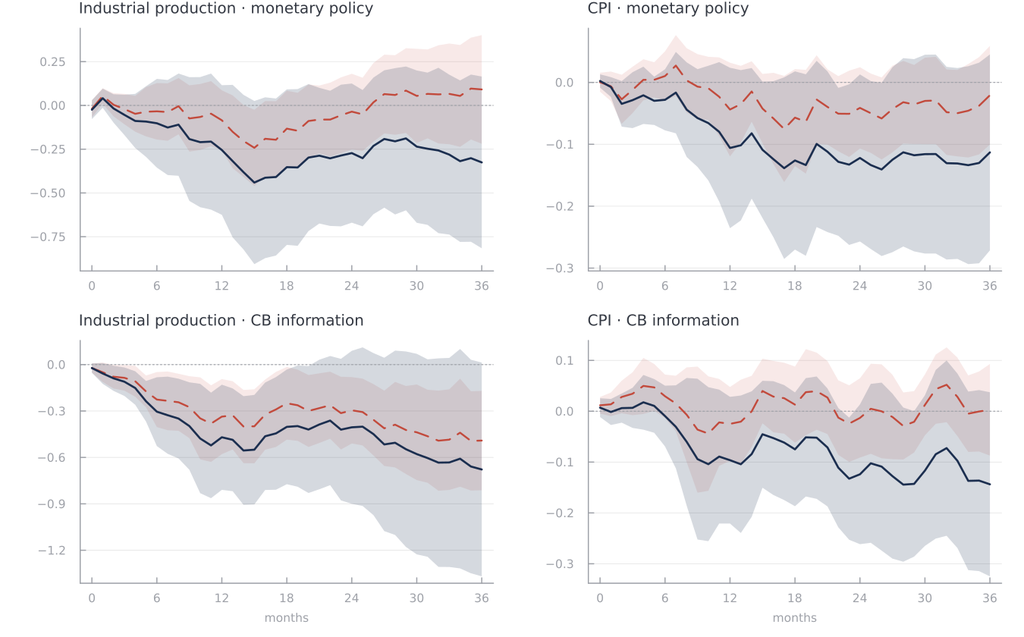

Responses to a one-standard-deviation shock. Solid navy: long differences; dashed brick: levels. 90% bands, Newey–West with 37 lags.

Three years after a monetary-policy shock, industrial production is **-0.33** in long differences and **0.09** in levels.

The two specifications agree over the first months and then part. In levels the responses drift back toward zero at long horizons; in long differences they stay persistent. The price is precision: at 36 months the long-difference standard errors are 1.58 to 2.15 times the levels ones across the four panels. This is the trade-off the paper studies. In its simulations, levels projections on persistent data are biased toward zero at long horizons, and long differences remove much of that bias at the cost of a larger variance.

| h | long diff. | s.e. | levels | s.e. |
| --- | --- | --- | --- | --- |
| 0 | -0.024 | 0.033 | -0.019 | 0.030 |
| 6 | -0.102 | 0.154 | -0.034 | 0.098 |
| 12 | -0.255 | 0.225 | -0.085 | 0.104 |
| 18 | -0.353 | 0.270 | -0.133 | 0.132 |
| 24 | -0.272 | 0.242 | -0.036 | 0.132 |
| 30 | -0.235 | 0.265 | 0.054 | 0.164 |
| 36 | -0.326 | 0.298 | 0.091 | 0.189 |

## Checks

The long-difference response is an anchored response, $y_{t+h}$ minus a baseline fixed at $t$, with the baseline $y_{t-1}$. Written with `anchor`, the same regression gives the same path:

```julia
anchored = lp(@formula(anchor(lip, lag(lip)) ~ mp + lags(firstdiff(lip), 12) +
                       lags(firstdiff(lcpi), 12) + lags(firstdiff(lsp500), 12) +
                       lags(firstdiff(ebp), 12) + lags(firstdiff(gs1), 12)), ps;
    horizon = 36)
maximum(abs.(coefpath(anchored) .- coefpath(diffs)))
```

```
0.0
```

And the regression at any single horizon is ordinary least squares on columns built by hand, the way their MATLAB loop builds them:

```julia
h = 24
T = nrow(ps)
rows = 14:(T - h)                                   # 1990:2 to T − h
Δ(v) = [NaN; diff(Float64.(v))]
X = hcat(Float64.(ps.mp[rows]), ones(length(rows)),
    [Δ(ps[!, v])[rows .- j] for v in (:lip, :lcpi, :lsp500, :ebp, :gs1), j in 1:12]...)
Y = ps.lip[rows .+ h] .- ps.lip[rows .- 1]
(by_hand = (X \ Y)[1], ldiff = coefpath(diffs)[h + 1])
```

```
(by_hand = -0.27233853739248953, ldiff = -0.27233853739248887)
```

Beyond this page, the paths were checked against Stata (`newey, lag(37)` on variables built with time-series operators) and against a line-by-line port of the authors’ MATLAB loop, including its Newey–West sum. The long-difference coefficients and standard errors agree with both to $10^{-14}$ at every horizon, on identical samples; the levels ones to $10^{-6}$, the precision allowed by 61 nearly collinear log-level regressors.

## Other long-difference responses

`ldiff` has two relatives. `cumul(ldiff(y))` sums the long differences over horizons $0, \dots, h$, for cumulative responses. `hbr(x, y)` divides the change by a lagged scale variable, $(x_{t+h} - x_{t-1}) / y_{t-1}$: the Hall–Barro–Redlick transformation used for fiscal multipliers, where output and spending changes are both measured as shares of lagged GDP. All of them can also appear on the right-hand side, as the instrumented regressor of a cumulative multiplier:

```julia
lpiv(TSLS(), @formula(cumul(hbr(gdp)) ~ (cumul(hbr(gov, gdp)) ~ news) +
              lags(news, 4) + lags(log(gdp), 4) + lags(log(gov), 4)), df; horizon = 20)
```